# Section C: Distribution of Teacher Resources in Washington

Pooya Almasi

November 10, 2021

C.1 Regionalization Factor Bar Graph separately for 2018-19; 2019-20 (difference in regionalization factor levels between years): G1=1; men=average poverty rate; women=average share of students of color

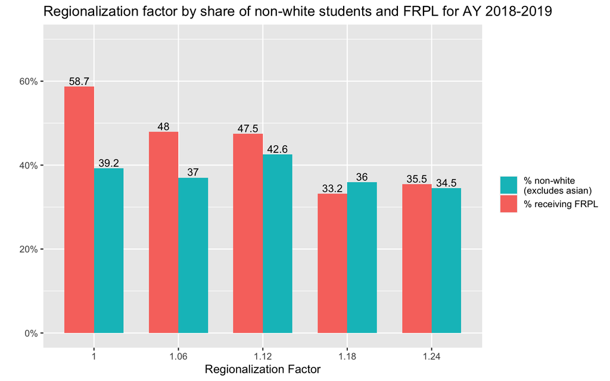

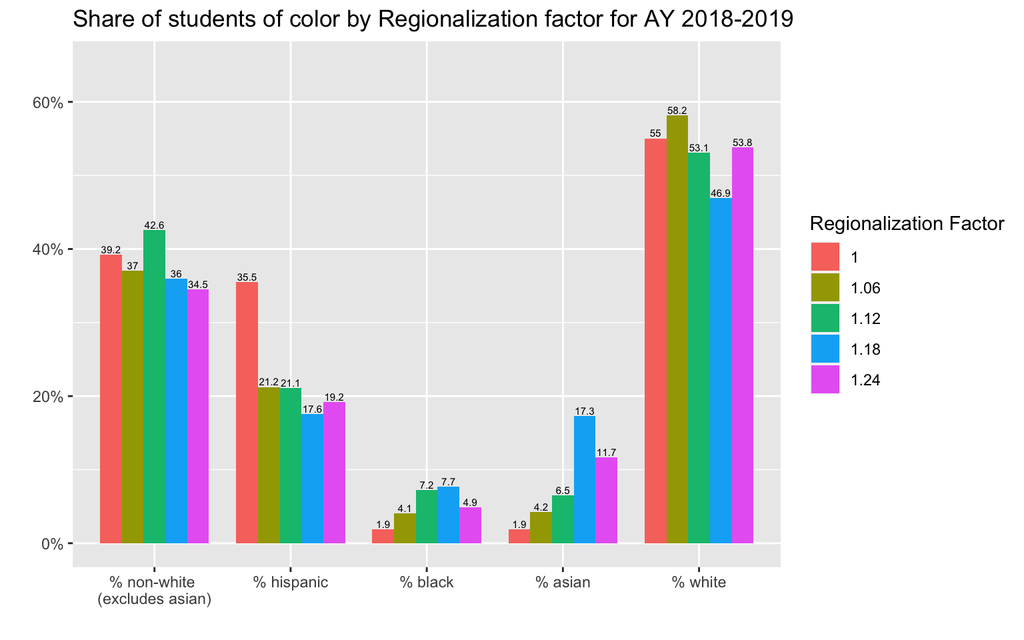

C.2. Regionalization correlated with teacher salary adjusted local non-teacher wages (which is in the cost index database). Use either bar graph as above, or use the correlation scatter plot similar as below (regionalization factor will be in the x-axis, while average teacher salary for each district in 2019-20 [adjusted for local non-teacher wages] will be in the y-axis).

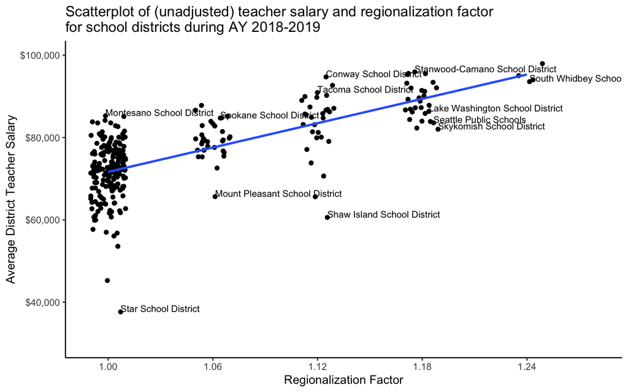

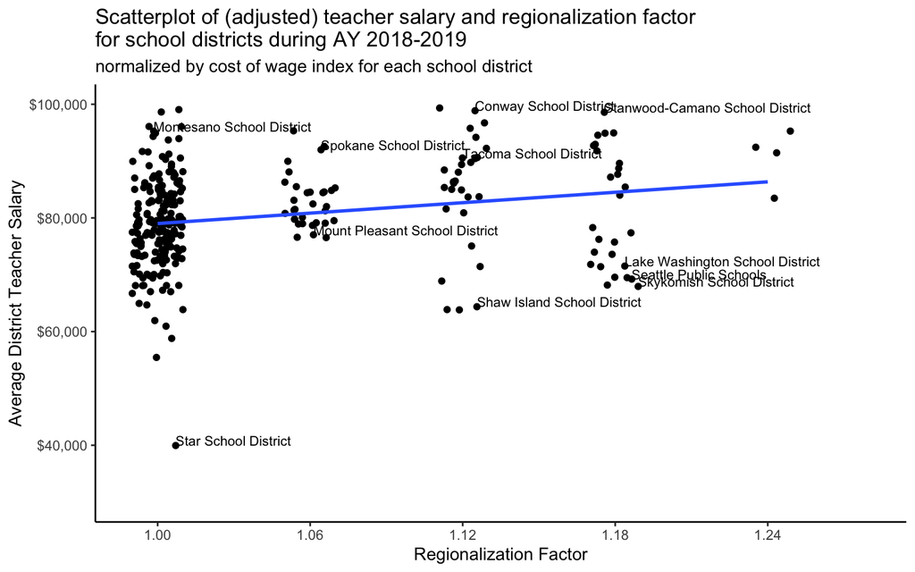

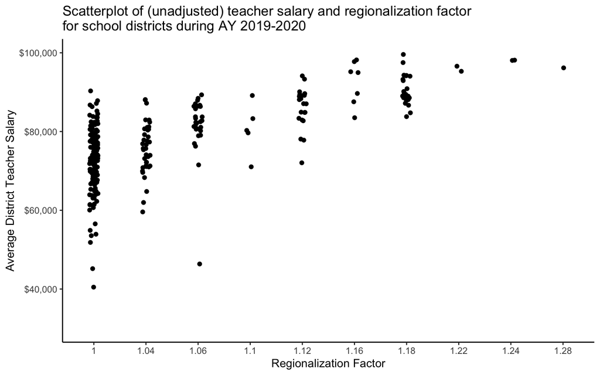